# FUNDAMENTOS DE DATA SCIENCE - PROJETO FINAL

### **ANÁLISE DO TRÁGICO ACIDENTE DO TITANIC OCORRIDO EM 1912**

## 1.0 - CONTEXTO HISTÓRICO E ANÁLISE

[figure not shown]

## 2.0 - VISUALIZANDO DADOS

```python
# INICIALIZANDO O MATPLOTLIB
%matplotlib inline

# IMPORTANDO BIBLIOTECAS PARA A EXECUÇÃO DA ANÁLISE
import numpy as np
import pandas as pd
import matplotlib.pyplot as plt
import seaborn as sns

# CARREGANDO O CONJUNTO DE DADOS
titanic_cdo = pd.read_csv('titanic-data-6.csv')
# EXIBINDO AS CINCO PRIMEIRAS LINHAS DE DADOS DO CONJUNTO DE DADOS
titanic_cdo.head()
```

|  | PassengerId | Survived | Pclass | Name | Sex | Age | SibSp | Parch | Ticket | Fare | Cabin | Embarked |
| --- | --- | --- | --- | --- | --- | --- | --- | --- | --- | --- | --- | --- |
| 0 | 1 | 0 | 3 | Braund, Mr. Owen Harris | male | 22.0 | 1 | 0 | A/5 21171 | 7.2500 | NaN | S |
| 1 | 2 | 1 | 1 | Cumings, Mrs. John Bradley (Florence Briggs Th... | female | 38.0 | 1 | 0 | PC 17599 | 71.2833 | C85 | C |
| 2 | 3 | 1 | 3 | Heikkinen, Miss. Laina | female | 26.0 | 0 | 0 | STON/O2. 3101282 | 7.9250 | NaN | S |
| 3 | 4 | 1 | 1 | Futrelle, Mrs. Jacques Heath (Lily May Peel) | female | 35.0 | 1 | 0 | 113803 | 53.1000 | C123 | S |
| 4 | 5 | 0 | 3 | Allen, Mr. William Henry | male | 35.0 | 0 | 0 | 373450 | 8.0500 | NaN | S |

## 2.1 - DESCRIÇÃO DOS ATRIBUTOS DO CONJUNTO DE DADOS

Diante do conjunto de dados podemos observar vários atributos, tais como: PassengerId, Survived, Pclass, Name, Sex, Age, SibSp, Parch, Ticket, Fare, Cabin, Embarked. Logo, podemos caracterizar com descrições cada um deles.

**PassengerId**: Identificação do passageiro dentro do conjunto de dados.

**Survived**: Resultado da sobrevivência. (Representado por: 0(Não) ou 1(Sim))

**Pclass**: Classe sócio-econômica. (Representado por: 1(Classe Alta), 2(Classe Média) ou 3(Classe Baixa))

**Name**: Nome do passageiro.

**Sex**: Sexo do passageiro.

**Age**: Idade do passageiro.

**SibSp**: Número de irmãos e cônjuges do passageiro a bordo.

**Parch**: Número de pais e filhos do passageiro a bordo.

**Ticket**: Número do bilhete do passageiro.

**Fare**: Tarifa paga pelo passageiro.

**Cabin**: Número da cabine em que o passageiro embarcou.

**Embarked**: Porto de embarque do passageiro (Representado por: C(Cherbourg), Q(Queenstown) ou S(Southampton))

## 2.2 - LIMPEZA DO CONJUNTO DE DADOS

De acordo com a descrição do conjunto de dados com a minha análise, conclui que algumas colunas existentes no conjunto não serão necessárias na minha análise, e para que não sobrecarregue ou qualquer coisa do tipo, tais colunas serão removidas desencadeando também uma melhora no processamento de desempenho.

Além do processo de limpeza abordado, sendo eles:

- Identificar e excluir dados duplicados.
- Apagar colunas que não serão necessárias para a análise.
- Corrigir problema de conversão de dados e a falta deles.

## 2.2.1 - IDENTIFICAÇÃO E EXCLUSÃO DE DADOS DUPLICADOS

```python
tid = titanic_cdo.duplicated()
print('Há {} dados duplicados existentes no conjunto de dados.'.format(tid.sum()))
```

```
Há 0 dados duplicados existentes no conjunto de dados.
```

## 2.2.2 - APAGANDO COLUNAS

```python
titanic_cdn = titanic_cdo.drop(['PassengerId', 'Name', 'Ticket', 'Fare', 'Embarked', 'Cabin'], axis=1)
titanic_cdn.head()
```

|  | Survived | Pclass | Sex | Age | SibSp | Parch |
| --- | --- | --- | --- | --- | --- | --- |
| 0 | 0 | 3 | male | 22.0 | 1 | 0 |
| 1 | 1 | 1 | female | 38.0 | 1 | 0 |
| 2 | 1 | 3 | female | 26.0 | 0 | 0 |
| 3 | 1 | 1 | female | 35.0 | 1 | 0 |
| 4 | 0 | 3 | male | 35.0 | 0 | 0 |

## 2.2.3 - CORRIGINDO PROBLEMAS DE CONVERSÃO DE DADOS E A FALTA DE DADOS

```python
# VERIFICANDO DADOS NULOS
titanic_cdn.isnull().sum()
```

```
Survived      0
Pclass        0
Sex           0
Age         177
SibSp         0
Parch         0
dtype: int64
```

É possível notar que há 177 dados nulos na coluna **Age**.

```python
# PREENCHENDO DADOS NULOS
titanic_cdn.Age.fillna(titanic_cdn.Age.mean(),inplace=True)
```

## 3.0.0 - QUESTIONAMENTOS

## 3.1.0 - Há uma quantidade maior de sobreviventes do gênero masculino ou feminino?

### 3.1.1 - Gráfico de comparação.

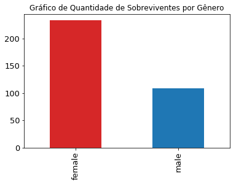

```python
titanic_cdn['Not Survived'] = titanic_cdn['Survived'].map({0:1,1:0}).copy()
titanic_cdn.query('Survived==1')['Sex'].value_counts().plot(kind='bar', title='Gráfico de Quantidade de Sobreviventes por Gênero', fontsize=13, color=('tab:red', 'tab:blue'))
```

### 3.2.0 - O maior número de sobreviventes foram crianças/adolescentes ou adultos?

```
Survived                 1
rAge
Crianças/Adolescentes   61
Adultos                281
```

```
Text(0,0.5,'Quantidade')
```

[figure not shown]

```python
%matplotlib inline

# ADICIONANDO O RANGE DA FAIXA DE IDADE
ranges=[0,17,80]
range_labels=['Crianças/Adolescentes','Adultos']
titanic_cdn['rAge']=pd.cut(titanic_cdn['Age'],ranges,labels=range_labels)

# EXIBINDO A QUANTIDADE DE CRIANÇAS/ADOLESCENTES E ADULTOS QUE EMBARCARAM NO RMS TITANIC
titanic_cdn.groupby('rAge').Survived.count()

# EXTRAINDO DADOS E EXIBINDO A QUANTIDADE DE SOBREVIVENTES ENTRE CRIANÇAS/ADOLESCENTES E ADULTOS
titanic_bage = titanic_cdn.query('Survived==1').groupby(['rAge', 'Survived'],as_index=False).size().unstack()
print(titanic_bage)

# EXIBINDO O GRÁFICO
titanic_bage.plot.barh(figsize=(10,5))
plt.title('Sobreviventes por idade',fontsize=20)
plt.xlabel('Idade',fontsize=15)
plt.ylabel('Quantidade',fontsize=15)
```

### 3.3.0 - Qual é a porcentagem de sobreviventes em comparação aos tripulantes a bordo durante a viagem?

```
Text(0,0.5,'')
```

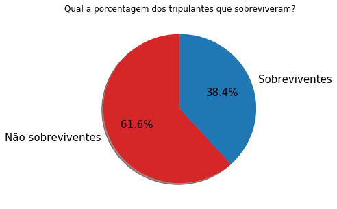

```python
titanic_cdn['Not Survived'] = titanic_cdn['Survived'].map({0:1,1:0}).copy()
titanic_cdn['Survived'].value_counts().plot.pie(colors=('tab:red', 'tab:blue'), title='Qual a porcentagem dos tripulantes que sobreviveram?', fontsize=15, autopct='%1.1f%%', shadow=True, startangle=90, labels=('Não sobreviventes','Sobreviventes'), figsize=(5,5)).set_ylabel('')
```

## 4.0.0 - CONCLUSÃO

Podemos concluir com essa análise é que levando em consideração que os dados não estejam 100% preenchidos, com a falta de dados a eficiência da precisão da análise pode não ser 100% também, devido a qualidade do conjunto de dados da Tragédia do RMS Titanic.

Visto que na hora do desespero dos tripulantes não teria tanta preocupação em mente para a priorização de indivíduos por classe, não foi realizado uma análise sobre o mesmo levando em conta o resultado das análises realizadas que levaria a uma grande chance do possível fato ter ocorrido.

E de acordo com a porcentagem da análise realizada, o famoso RMS Titanic não foi planejado com uma grande quantidade de botes suficiente para satisfazer a todos os tripulantes, o que pode nos dizer que o návio estava totalmente despreparado para uma situação como essa que aconteceu, o que foi uma grande tragédia e perda para todos.